# ARMA/ARIMA/SARIMA

Stationarity, Differencing, Model Fitting, Diagnostics, Forcasting, and Validation

## ARIMA - CPI

I choose the `ARIMA` model for forecasting economic indicators because it’s useful for forecasting a series where the data points are independent of the seasonal components, which is the case with the economic indicators such as `CPI`, `GDP`, `USD index`, `unemployment rate`, and `mortgage rate`. These indicators typically have underlying trends or cycles that ARIMA can address through differencing, making the data stationary before applying auto-regressive and moving average components to capture the relationships in the data.

### Data Processing

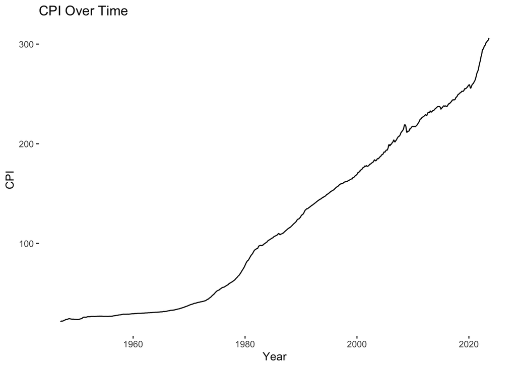

### Stationarity Check

Initial assessments via `ACF` and `Augmented Dickey-Fuller` tests indicated that `CPI` required differencing due to non-stationarity. After converting to a time series and applying logarithmic transformation, first differencing was insufficient in detrending, but second differencing indicated stationarity.

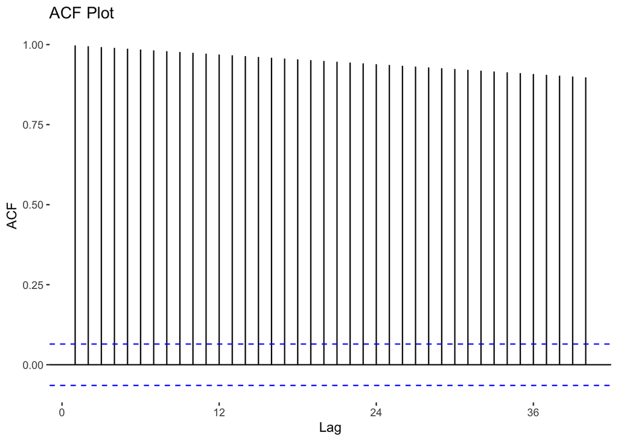

```
Augmented Dickey-Fuller Test Results:
```

```
Test Statistic: -0.8219849   P-value: 0.959648
```

```
The time series is not stationary based on the ADF test.
```

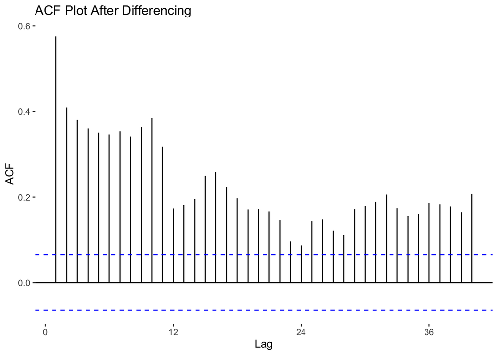

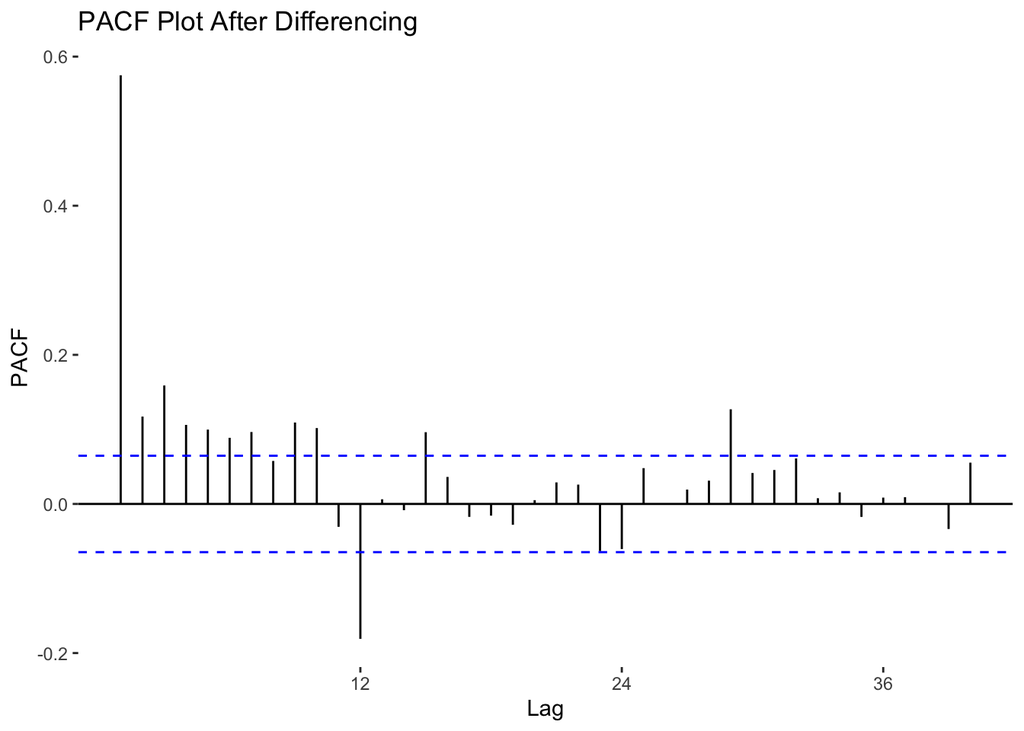

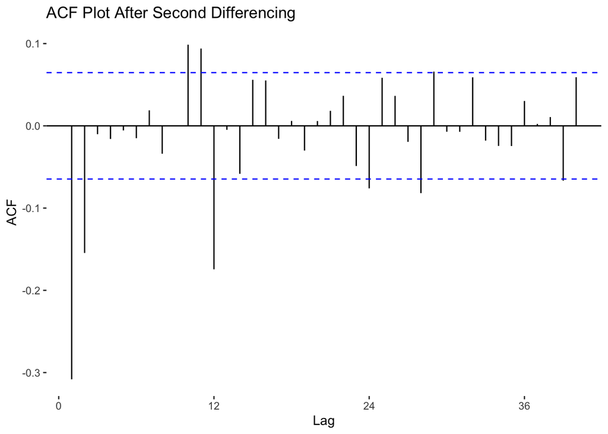

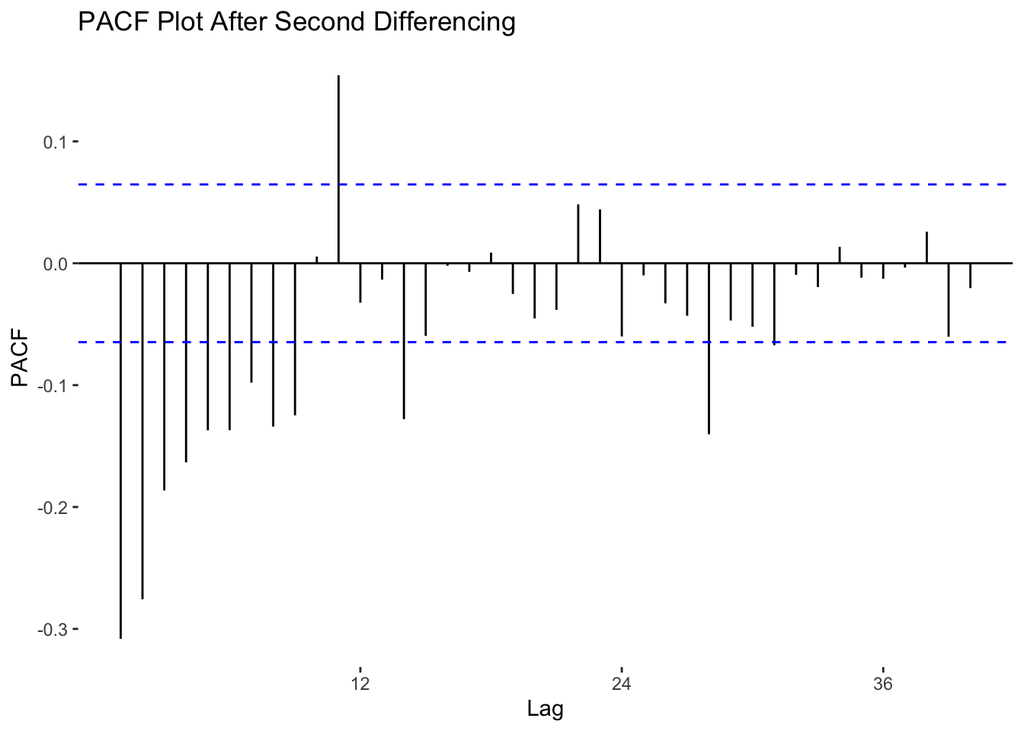